# Machine Learning Assignment

## Machine Learning Assignment - by Federico Natali

The purpose of this research is to develop and compare different recommendations algorithms using different distance definitions in order to find the best performing one. Validation is done using bootstrap on the training set.

```r
#func to check if library is installed, in not install it
check.packages <- function(pkg){
  new.pkg <- pkg[!(pkg %in% installed.packages()[, "Package"])]
  if (length(new.pkg))
    install.packages(new.pkg, dependencies = TRUE)
  sapply(pkg, require, character.only = TRUE)
}
```

```r
packageList<-c("ggplot2", "data.table", "reshape2", "recommenderlab", "recosystem",'dplyr','here','ggplot2')
check.packages(packageList)
```

```r
#Load required libraries
library(recommenderlab)
library(ggplot2)
library(data.table)
library(reshape2)
library(dplyr)
library(here)
library(ggplot2)
```

```r
#Use fread to process data faster
movie_data <- data.table::fread("data/ml-latest/movies.csv",stringsAsFactors=FALSE)
rating_data <- data.table::fread("data/ml-latest/ratings.csv")
```

```r
#Check number of duplicate items
length(movie_data$movieId) - length(unique(movie_data$movieId))
```

```
## [1] 0
```

```r
length(movie_data$title) - length(unique(movie_data$title))
```

```
## [1] 78
```

The first operation returns 0, which means there are no duplicate movieID. However the second returns a number greater than zero, which means some movie with the same title might have different ID. Let’s look for them.

```r
#Check if movie with same titles are represented with different IDs
repeatMovies <- which(table(movie_data$title) > 1)
head(repeatMovies,5)
```

```
## 20,000 Leagues Under the Sea (1997)                   Absolution (2015)
##                                 348                                1674
##                    Aftermath (2012)                      Aladdin (1992)
##                                2069                                2238
##                Another World (2014)
##                                3513
```

Example of movies with same title and different movieID. Also note that Genre is different as well

ID 5264 | Title Clockstoppers (2002) | Genre Action|Adventure|Sci-Fi|Thriller  
ID 144426 | Title Clockstoppers (2002) | Genre Adventure|Children|Sci-Fi|Thriller

For simplicity I will remove all duplicate instances.

```r
#remove all duplicate items based on column 'title'
movie_data <- unique(movie_data, by='title')

#Check again if movies with duplicate titles have been removed
repeatMovies <- which(table(movie_data$title) > 1)
repeatMovies
```

```
## named integer(0)
```

There are not anymore movies with the same title now.

Let’s have a look at ratings data now.

```r
#rating_data %>% group_by(userId) %>% count(movieId) %>% filter(n>1)
```

There are no duplicates eg. the same user did not rate the same movie more than once

```r
not_rated <- setdiff(unique(movie_data$movieId), unique(rating_data$movieId)) #movies not rated by any user

#I will remove these movies as they can not be used as input to our reccomender.

'%ni%' <- Negate('%in%') #Function that works in the opposite way of %in%.

movie_len1 <- length(movie_data$movieId)
movie_data <- movie_data[movieId %ni% not_rated]
movie_len2 <- length(movie_data$movieId)
movie_delta <- movie_len1 - movie_len2
```

There were initially 58020 movies, and 4204 movies had no reviews thus were eliminated.

```r
genres_all <- unique(movie_data[1:10000]$genres)
genres <- c()

#function to generates list of all genres using those in the first Nth movies.
for (i in genres_all) {
  i <- strsplit(i, split = "\\|") #break on escape char
  genres <- append(genres, i[[1]])
}

genres <- unlist(unique(as.list(unlist(genres)))) #unlist and re-list to get data at same levels, and then only get unique values

genres <- data.frame(genres)
```

## Data Preparation

First of all we normalize ratings data as we want to remove rating bias from those users who always give very high or very low ratings.

```r
rating_data <- head(rating_data,500000)
```

```r
ratingMatrix <- dcast.data.table(rating_data, userId~movieId, value.var = "rating")
ratingMatrix <- as.matrix(ratingMatrix[,-1])

dim(ratingMatrix)
```

```
## [1]  5081 17821
```

```r
#setdiff(movie_data$movieId, as.integer(colnames(ratingMatrix)))

#We cast the matrix to type 'realRatingMatrix which will later be fed to the recommender object
ratingMatrix <- as(ratingMatrix, "realRatingMatrix")
```

```r
user_similarity <- similarity(ratingMatrix[1:10, ],
                             method = "cosine",
                             which = "users")

user_similarity
```

```
##            1         2         3         4         5         6         7
## 2         NA
## 3         NA        NA
## 4  0.9543216 1.0000000 0.9983142
## 5         NA 1.0000000        NA 0.9710029
## 6  1.0000000 1.0000000        NA 0.9562122 0.9839914
## 7         NA        NA        NA 0.8233293 1.0000000        NA
## 8         NA        NA        NA 0.9690507        NA 1.0000000        NA
## 9         NA        NA        NA 1.0000000 1.0000000        NA        NA
## 10        NA 1.0000000        NA 0.9464202 0.9928415 0.9830149        NA
##            8         9
## 2
## 3
## 4
## 5
## 6
## 7
## 8
## 9         NA
## 10 0.9701425        NA
```

```r
movie_ratings <- ratingMatrix[rowCounts(ratingMatrix) > 25,
                              colCounts(ratingMatrix) > 25]
## If we changed this number the performance of the final model is likely to change as well. For very small numbers the performance will go down. When sample if limited large numbers (instead of 50) will also decrease performance
movie_ratings
```

```
## 2744 x 3215 rating matrix of class 'realRatingMatrix' with 400972 ratings.
```

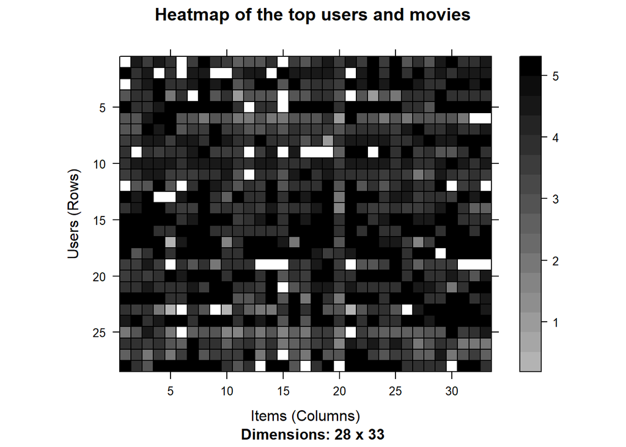

```r
minimum_movies<- quantile(rowCounts(movie_ratings), 0.99)
minimum_users <- quantile(colCounts(movie_ratings), 0.99)

image(movie_ratings[rowCounts(movie_ratings) > minimum_movies,
                    colCounts(movie_ratings) > minimum_users],
      main = "Heatmap of the top users and movies")
```

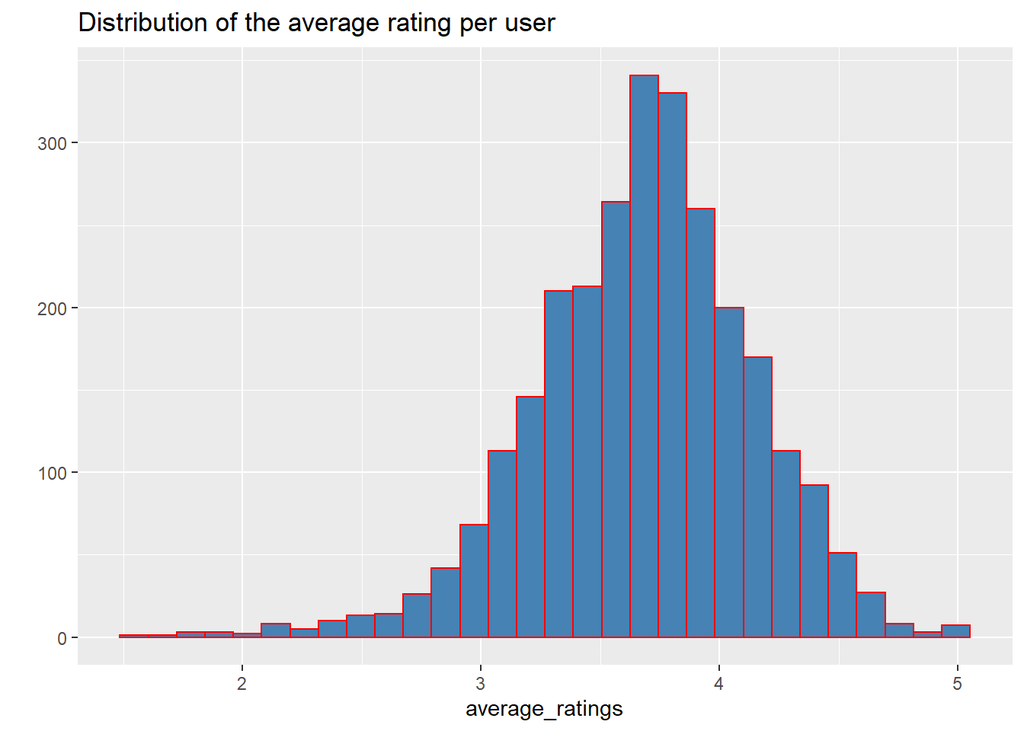

```r
average_ratings <- rowMeans(movie_ratings)
qplot(average_ratings, fill=I("steelblue"), col=I("red")) +
  ggtitle("Distribution of the average rating per user")
```

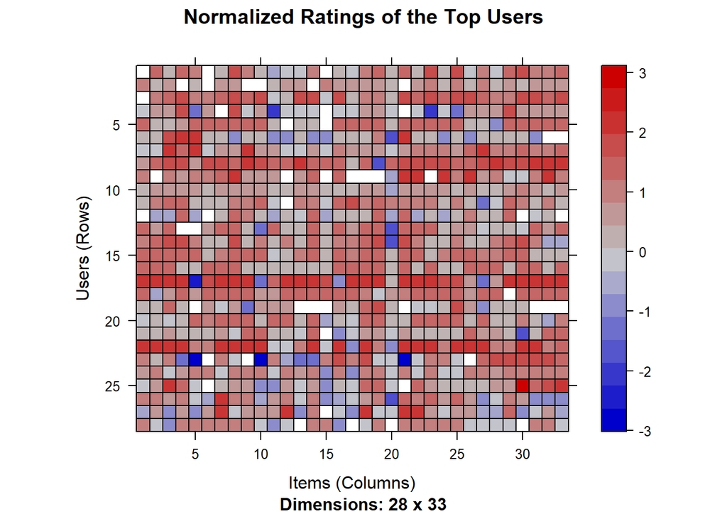

```r
normalized_ratings <- normalize(movie_ratings)
image(normalized_ratings[rowCounts(normalized_ratings) > minimum_movies,
                         colCounts(normalized_ratings) > minimum_users],
      main = "Normalized Ratings of the Top Users")
```

```r
normalized_ratings
```

```
## 2744 x 3215 rating matrix of class 'realRatingMatrix' with 400972 ratings.
## Normalized using center on rows.
```

```r
#Create evaluation scheme to be used for validation
scheme <- evaluationScheme(movie_ratings,
                           method="bootstrap",
                           k=5,
                           given=2,
                           goodRating=5)
```

## User Based Collaborative Filtering (UBCF)

Here we try to see which parameters are the best when using UBCF reccomendation on this specific dataset.

```r
##User Based Collaborative Filtering (UBCF) ##

#Tuning for best distance method and best value for 'nn'

algorithms_ubcf <- list("Cosine 30" = list(name="UBCF", param=list(normalize = "center", method="cosine", nn=30)),
                   "Cosine 15" = list(name="UBCF", param=list(normalize = "center", method="cosine", nn=15)),
                   "Pearson 30" = list(name="UBCF", param=list(normalize = "center", method="pearson", nn=30)),
                   "Pearson 15" = list(name="UBCF", param=list(normalize = "center", method="pearson", nn=15)),
                   "Jaccard 30" = list(name="UBCF", param=list(normalize = "center", method="jaccard", nn=30)),
                   "Jaccard 15" = list(name="UBCF", param=list(normalize = "center", method="jaccard", nn=15)))

ubcf_results_ratings <- evaluate(scheme, algorithms_ubcf, type='ratings')
ubcf_results_topN <- evaluate(scheme, algorithms_ubcf, type = "topNList",   n=c(1,3,5,10,15,20))
```

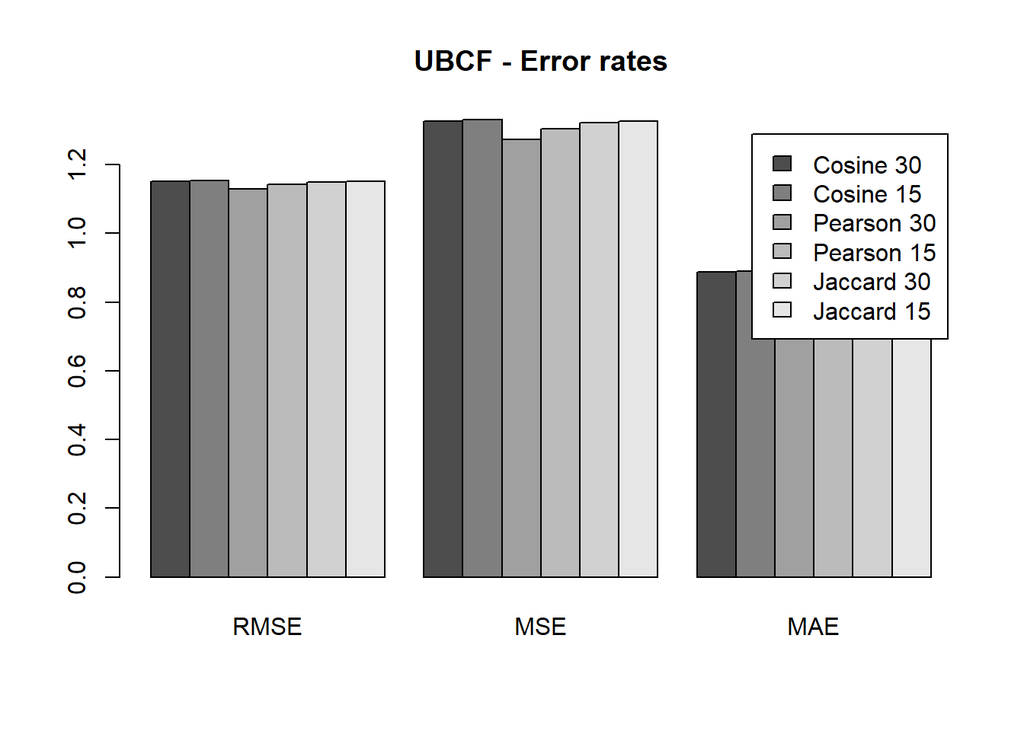

```r
#Comparison of RMSE, MSE, and MAE for different UBCF recommender methods for the given evaluation scheme
plot(ubcf_results_ratings, annotate = TRUE) + title('UBCF - Error rates')
```

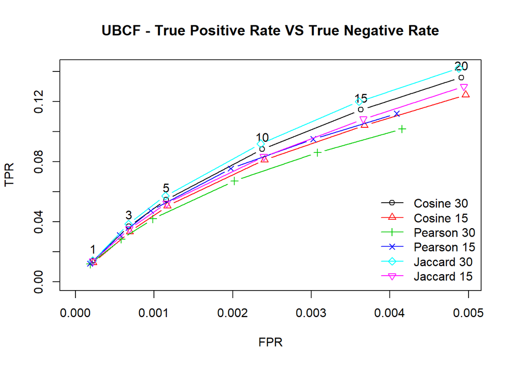

```r
#Comparison  of  TPR/TNR  for different UBCF recommender  methods  for  the  given evaluation scheme.
plot(ubcf_results_topN, annotate = TRUE) + title('UBCF - True Positive Rate VS True Negative Rate')
```

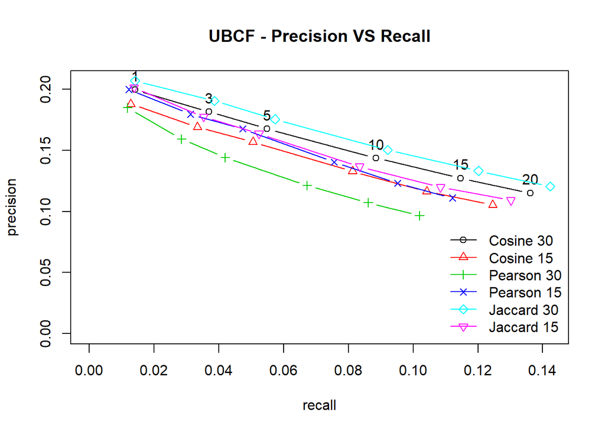

```r
#Comparison  of  ROC  curves  for  different UBCF  recommender  methods  for  the  given evaluation scheme.
plot(ubcf_results_topN, "prec/rec",annotate = TRUE) + title('UBCF - Precision VS Recall')
```

When using Pearson distance with UBCF the algo takes significantly less time compared to Cosine and Jaccard, furthermore, the error rate is smaller as well.

## Item Based Collaborative Filtering (IBCF)

Here we try to see which parameters are the best when using IBCF reccomendation on this specific dataset.

```r
##Item Based Collaborative Filtering (IBCF) ##

scheme_ibcf <- evaluationScheme(movie_ratings,
                           method="split",
                           train=0.9,
                           given=3,
                           goodRating=5)

#Tuning for best distance method and best value for 'k'

algorithms_ibcf <- list("IBCF Cosine 30" = list(name="IBCF", param=list(normalize = "center", method="cosine", k=15)),
                   "IBCF Pearson 30" = list(name="IBCF", param=list(normalize = "center", method="pearson", k=15)),
                   "IBCF Jaccard 30" = list(name="IBCF", param=list(normalize = "center", method="jaccard", k=15)))

ibcf_results_ratings <- evaluate(scheme_ibcf, algorithms_ibcf, type='ratings')
```

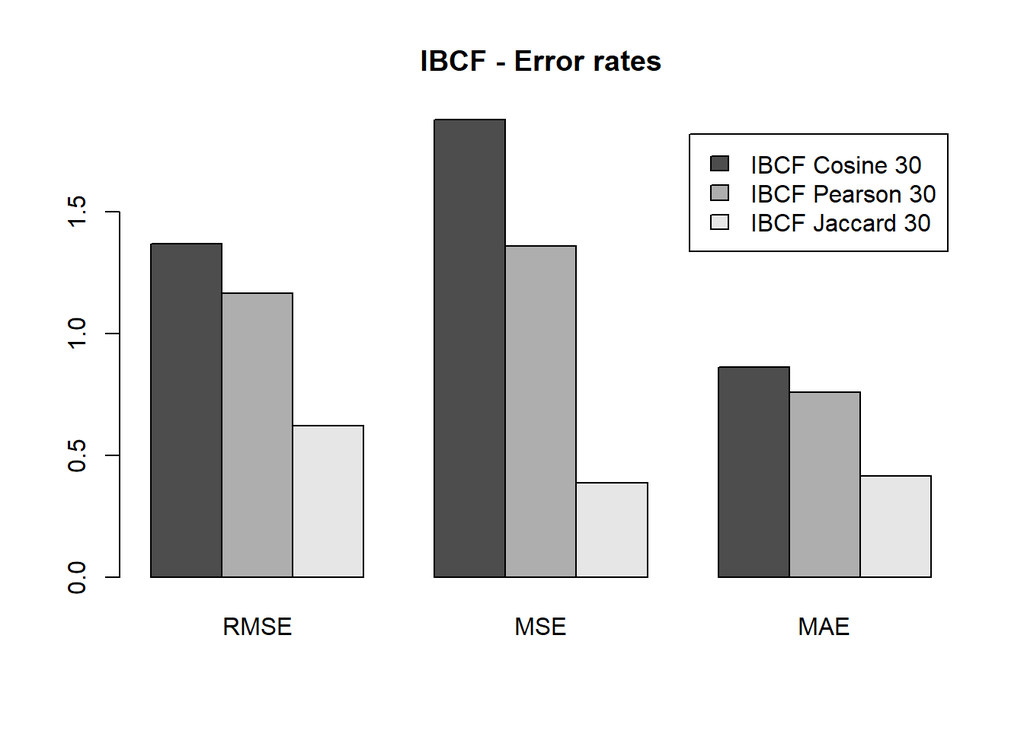

```r
#Comparison of RMSE, MSE, and MAE for different IBCF recommender methods for the given evaluation scheme
plot(ibcf_results_ratings, annotate = TRUE) + title('IBCF - Error rates')
```

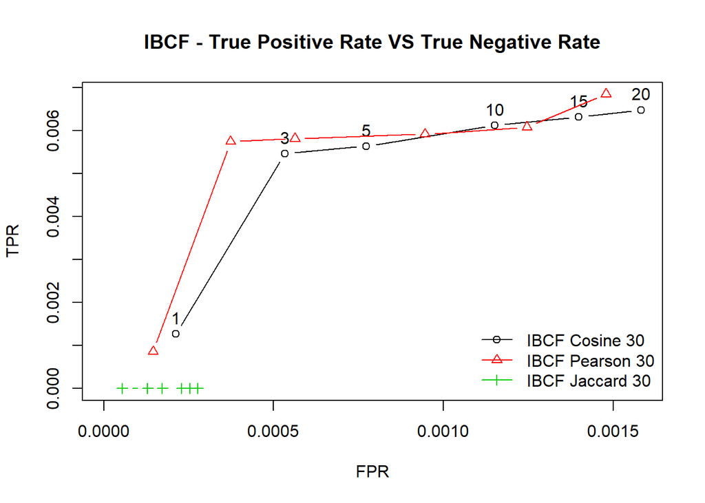

```r
#Comparison  of  TPR/TNR  for different IBCF recommender  methods  for  the  given evaluation scheme.
plot(ibcf_results_topN, annotate = TRUE) + title('IBCF - True Positive Rate VS True Negative Rate')
```

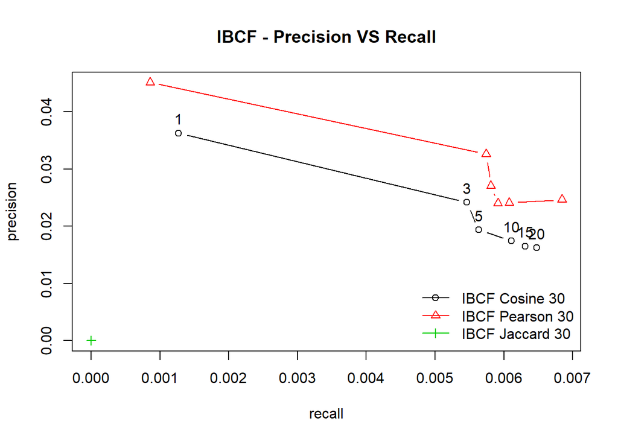

```r
#Comparison  of  ROC  curves  for  different IBCF  recommender  methods  for  the  given evaluation scheme.
plot(ibcf_results_topN, "prec/rec",annotate = TRUE) + title('IBCF - Precision VS Recall')
```

## Matrix Factorization Filtering (SVD)

Next, we use Singular Value Decomposition which is a method to factorize the rating matrix.

```r
##Matrix Based Collaborative Filtering (SVD) ##

#Tuning for different value of 'k'

algorithms_svd <- list("SVD 45" = list(name="SVD", param=list(k=45)),
  "SVD 30" = list(name="SVD", param=list(k=30)),
                   "SVD 15" = list(name="SVD", param=list(k=15)))


svd_results_ratings <- evaluate(scheme, algorithms_svd, type='ratings')
```

```r
svd_results_topN <- evaluate(scheme, algorithms_svd, type = "topNList",   n=c(1,3,5,10,15,20))
```

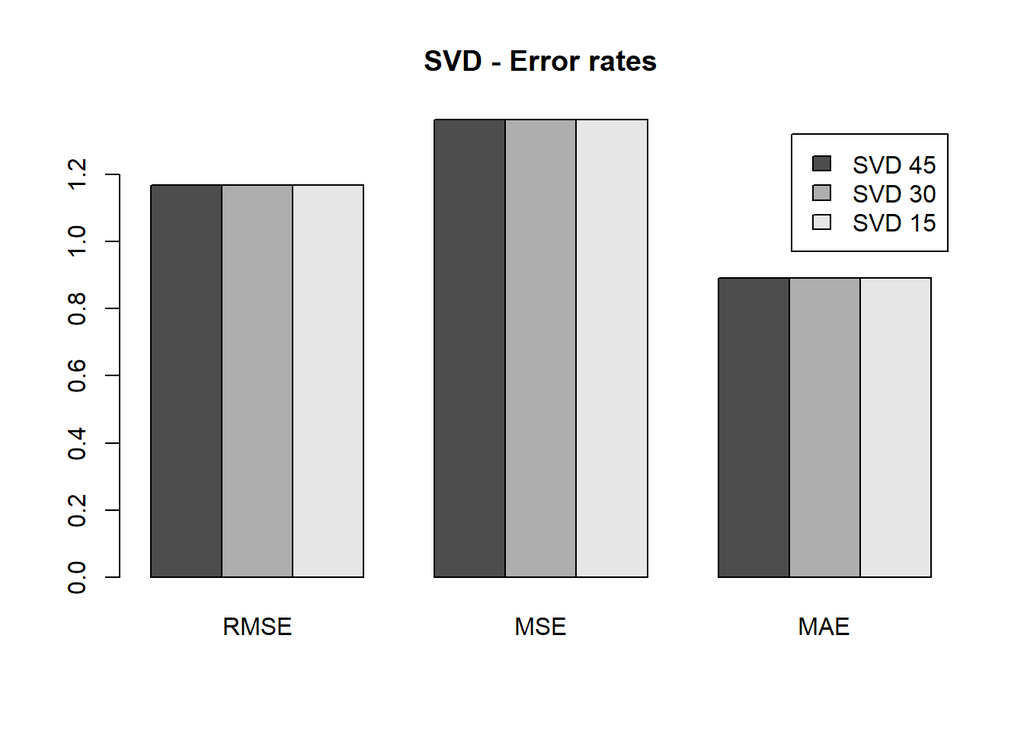

```r
#Comparison of RMSE, MSE, and MAE for different IBCF recommender methods for the given evaluation scheme
plot(svd_results_ratings, annotate = TRUE) + title('SVD - Error rates')
```

There are no significant differences for different values of k.

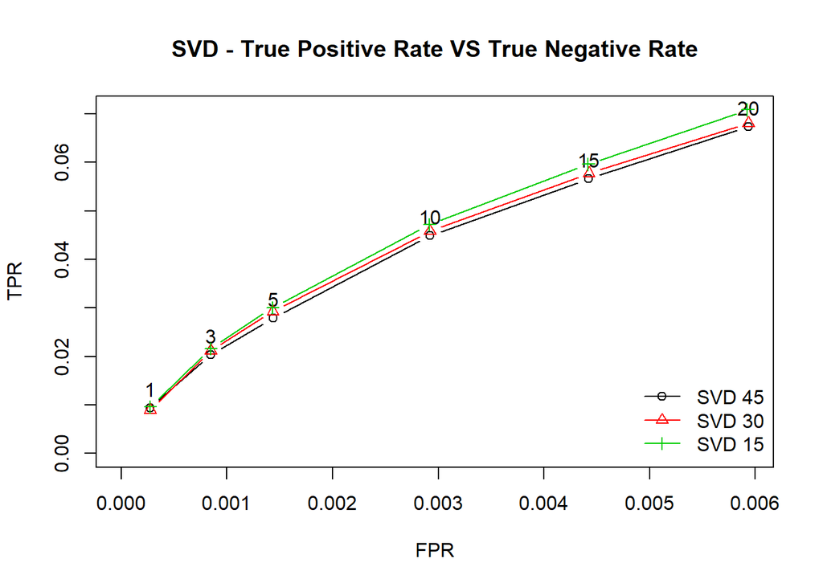

```r
#Comparison  of  TPR/TNR  for different IBCF recommender  methods  for  the  given evaluation scheme.
plot(svd_results_topN, annotate = TRUE) + title('SVD - True Positive Rate VS True Negative Rate')
```

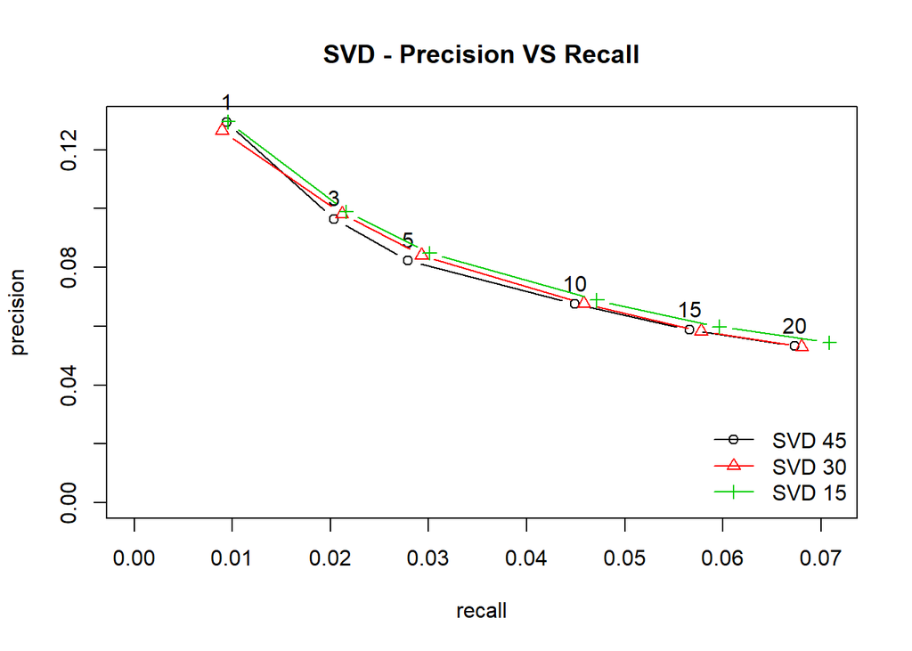

```r
#Comparison  of  ROC  curves  for  different IBCF  recommender  methods  for  the  given evaluation scheme.
plot(svd_results_topN, "prec/rec",annotate = TRUE) + title('SVD - Precision VS Recall')
```

SVD with lower k performs better.